# Reconnect_Demo

Jacqueline Oehri

2023-08-01

# Rapid Evaluation of Multispecies Connectivity (Reconnect)

Reconnect is a framework, accompanied by an R-package, that can be used to compute ecological connectivity indicators for multiple species and habitat needs across a region of interest.

## Summary

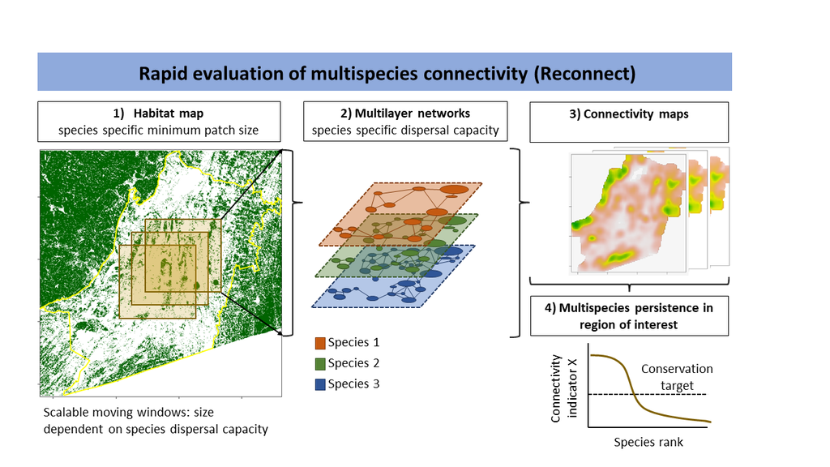

**Figure 1. Rapid Evaluation of Multispecies Connectivity (Reconnect) framework.** 1) Data input is a species (or ecoprofile) specific, binary habitat map that can be determined a priori (Albert et al., 2017; Meurant et al., 2018; B Rayfield et al., n.d.; Bronwyn Rayfield et al., 2016) or a posteriori from species distribution models (Liu, Newell, White, & Bennett, 2018; Rezaei, Mohammadi, Malakoutikhah, & Khosravi, 2022; Salgueiro et al., 2021; Shahnaseri et al., 2019; Tarabon, Bergès, Dutoit, & Isselin-Nondedeu, 2019). 2) In Reconnect, multiple habitat maps are “stacked” and multilayer habitat networks (Hartfelder et al., 2020; Hutchinson et al., 2018; Pilosof, Porter, Pascual, & Kéfi, 2017) extracted, in which links between habitat patches are determined by estimating species-specific dispersal probabilities (Hartfelder et al., 2020). Multilayer habitat networks can be computed in moving windows of different relevant sizes (Drielsma & Ferrier, 2009) and variable spatial overlap (Koen et al., 2019). 3) Multiple connectivity functions can be computed simultaneously across a range of species in the moving windows. With Reconnect, moving window results can then be aggregated into coherent maps of connectivity at pixel-level, patch-level or landscape-level for the species of interest. 4) The resulting maps can be used to evaluate connectivity indicators for multiple species.

### Note

The Reconnect [R-package](https://github.com/oehrij/Reconnect) used to implement the Reconnect framework is based and inspired by recently developed R-packages including Makurhini (Godínez-Gómez, O. and Correa Ayram C.A., 2020), gdistance (van Etten, 2017), igraph (Csardi & Nepusz, 2006), landscapemetrics (Hesselbarth, Sciaini, With, Wiegand, & Nowosad, 2019) and R-functions in refs. (Huang, Pimm, & Giri, 2020; Strimas-Mackey & Brodie, 2018). The main difference of Reconnect to these tools is that it is not focused on a specific set of connectivity indicators (cf. CONN_functions.R and MPC_functions.R in this package), rather, any connectivity indicator (that can be computed based on habitat distribution maps or resistance surfaces) could be defined and included in connectivity analyses. Similar to (Hughes et al., 2022), the Reconnect R-package aims at facilitating the flexible computation of connectivity indices simultaneously for multiple species and across a range of environmental contexts within a reasonable amount of time, and at reasonable spatial scales and resolution.

For questions and suggestions, please contact jacqueline.oehri@gmail.com

## Workflow Demo

### 1. Create a habitat map, a resistance map and a region of interest (roi)

```r
######################################################################
## set seed for reproducibility
set.seed(15)
##
### initialize parameters
nc1     = 250                                       ## define number of cells of landscape # 500 cells for dimx and dimy is reasonably good!!
hfr1    = c(0.15)                                   ## define fraction of habitat in landscape, in combination with npatches, this defines patch area
npatch1= c(100)                                     ## define number of patches (maximum nr should not be more than 10 times the number of cells..) in combination with hfrs, this defines patch area
sdpa1   = 0                                         ## define sd of patch area
cf1     = 1                                         ## clumping factor: 1 = non-overlapping patches, >1: clumped & overlapping patches
remedge1= TRUE                                      ## remove the edge of the landscape? - i.e. patches cannot go partially outside landscape
##
### make a simple circle simulation
res = simpcirc(dimx=nc1,dimy=nc1,hfr=hfr1,npatch=npatch1,sdpa=sdpa1,cf=cf1,form="circle",return="all",remedge=remedge1)
```

```
## [1] "creating patch areas with mean pa=93.8 and sdpa=0.0"
## [1] "sample landscape for final number of patches = 100"
## [1] "minimum distance = 10.9 units"
## [1] 0
## [1] "100 samples finished after 29 rounds"
## [1] "finished strata 0 going to next..."
```

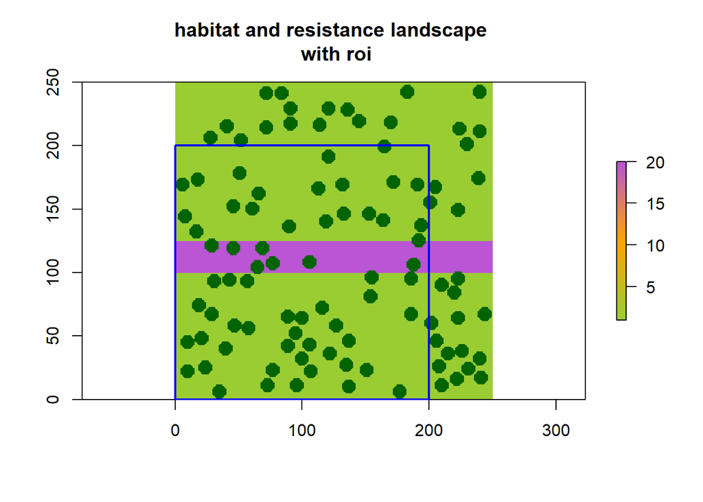

```r
##
### habitat raster
lcr = res$rast
##
### set roi to NULL to get the full extent
bbox = sf::st_bbox(lcr)
bbox[c(3,4)] = bbox[c(1,2)]+0.8*(bbox[c(3,4)]-bbox[c(1,2)])
roi  = sf::st_sf(ID= 1, geometry=sf::st_as_sfc(bbox))
sf::st_crs(roi) = sf::st_crs(lcr)
##
### make a resitance raster
lres = res$rast
## set all to 1 for the moment
lres[] = 1
## add a barrier whith resistance 20: cost distances should be *20 meters longer!
ncc = ncell(lres)
lres[round(ncc*0.5):round(ncc*0.6)] = 20
##
### plot for overview
par(mfrow=c(1,1))
plot(lres,col=JOcolsr1(100),main="habitat and resistance landscape \n with roi")
plot(lcr,col=c(NA,"darkgreen"),add=TRUE,legend=FALSE)
plot(roi$geometry,add=TRUE,col=NA,border="blue",lwd=2)
```

### 2. Define connectivity functions

Connectivity functions are described in the Reconnect_ini file! The average gap crossing distances are indicated in the “alphav” column of the inifile. The minimum habitat size requirements (that correspond to the gap crossing distances) are indicated in the “minsizev” column of the inifile.

#### Description of Reconnect_ini file:

- **conname**: User-defined name of connectivity function
- **resname**: User-defined name of connectivity function result(s)
- **confun**: recise name of connectivity function as defined in the corresponding R-package(s)
- **statement**: The confun-specific statement (should be of the form “confun(…)”).
  - Possible input objects prepared by Reconnect are:
    - Dispersal capacity (alpha1)
    - focal area (foc1)
    - shapefile of habitat patches (shp1)
    - raster file of habitat patches (lcr1: habitat = 1, non-habitat = NA; lcr2: habitat patches have values of shapefile id’s)
    - resistance file (re1)
    - vector of habitat patch areas (pa1) and matrix of pairwise distances (mdist1), both calculated using cost_type & dist_type settings
    - area of focal buffer (foc1a)
  - Next to these objects, connectivity function statement can specify any other object-independent arguments such as evec=FALSE in MPCser (type ?MPCser for more details).
- **resultnr**: In case the confun has several result outputs (e.g. list objects), the corresponding index can be specified as resultnr (should correspond to the “resname” content.
- **alphav**: Numeric values of desired gap crossing capacities, in units of the distances (usually meters)
- **minsizev**: Numeric values of alphav-specific minimum habitat patch areas, usually in meters-squared.
- **level**: Are connectivity functions applied at pixel, patch, and/or landscape-level?
- **aggfun**: Function to aggregate pixel and patch-level connectivity indicators to the landscape level
- **rpack**: R-package(s) of which confun should be taken.

```r
### set warnings off..
options(warn=-1)
## read inifile
#cond = readini(path=paste0(sourcedir,"/inifile/Reconnect_inifile_demo.xlsx"),sheet=1)
## for the vignette, save it as an RDA file
#saveRDS(cond,file=paste0(parent_dir,"/data/Reconnect_inifile_demo.rds"))
cond = readRDS(paste0(parent_dir,"/data/Reconnect_inifile_demo.rds"))
#print(cond)
#kable(cond)
paged_table(cond)
```

| conname | resname | confun | statement | resultnr | alphav | minsizev | level | aggfun | rpack |
| --- | --- | --- | --- | --- | --- | --- | --- | --- | --- |
| MPCser | MPCraw,MPCdens,MPCrmax | MPCser | confun(roi= foc1,pa=pa1,mdist=mdist1,alpha=alpha1) | 1,2,6 | 10,100,500 | NA | landscape | function(x){return(mean(x,na.rm=TRUE))} | REMC,RSpectra,landscapemetrics |
| MPCpimp | MPCpimp | MPC_fun | confun(pa=pa1,mdist=mdist1,alpha=alpha1) | 3 | 10,100,500 | NA | patch,landscape | function(x){return(mean(x,na.rm=TRUE))} | REMC,RSpectra,landscapemetrics |
| PCECA | ECA,ECA_AP | PCECA_fun | confun(pa=pa1,mdist=mdist1,alpha=alpha1,AL=foc1a) | 3,5 | 10,100,500 | NA | landscape | function(x){return(mean(x,na.rm=TRUE))} | REMC,landscapemetrics |
| PCECA_imp | ECAimp | dI_fun_alpha | confun(fun='PCECA_fun', expr='pa=x[[1]][-k],mdist=x[[2]][-k,-k],AL=x[[3]],alpha=alpha',x=list(pa=pa1,mdist=mdist1,AL=foc1a),resnr=c(2,3),alpha=alpha1,aslist=TRUE) | 2 | 10,100,500 | NA | patch,landscape | function(x){return(mean(x,na.rm=TRUE))} | REMC,landscapemetrics |
| Centrality | BC,ND | centr_igraph | confun(pa=pa1,mdist=mdist1,alpha=alpha1,cutoffpr=0.01) | 1,3 | 10,100,500 | NA | patch,landscape | function(x){return(mean(x,na.rm=TRUE))} | REMC,landscapemetrics,igraph |
| NND | NND | NNDf | confun(mdist=mdist1) | NA | NA | NA | patch,landscape | function(x){return(mean(x,na.rm=TRUE))} | REMC,landscapemetrics |
| eucdist | eucdist | eucdist_lm | confun(x=lcr1,dist_type="edge") | NA | NA | NA | pixel,landscape | function(x){return(mean(x,na.rm=TRUE))} | REMC,landscapemetrics |

```r
## Extract the dispersal distances from the inifile
## Alternatively, you could also set alphav = c(100,500)
alphav  = unique(unlist(strsplit(cond$alphav,split=",")))
alphav  = alphav[alphav!="NA"] %>% as.numeric %>% sort(decreasing=FALSE)
print("dispersal capacities (alphav) are as follows...")
```

```
## [1] "dispersal capacities (alphav) are as follows..."
```

```r
print(alphav)
```

```
## [1]  10 100 500
```

### 3. Decide on scales and resolution of interest

To show an example, we create a dataframe, where the desired raster resolution, the size of the moving windows (radius = 0.5*moving window sidelength) and the spatial overlap among windows (incr) is defined. Each row in the scaledf dataframe corresponds to a resolution x moving window size x spatial overlap configuration that can be taken as input in Reconnect. If “incr” is set to NA, Reconnect will only make 1 window of interest, centered in the middle of the region of interest.

```r
### Use scaledf function to make radii and resolution based on alphas and raster at hand
maxrad  = max((extent(lcr)[2]-extent(lcr)[1]),(extent(lcr)[4]-extent(lcr)[3]))/2
scaledf = data.frame(resolution=c(1,10),radius=c(80,maxrad),incr=c(50,NA))
print(scaledf)
```

```
##   resolution radius incr
## 1          1     80   50
## 2         10    125   NA
```

### 4. Set other Reconnect parameters

Type ?Reconnect_wrap to see all options. Most important settings concern distance calculations (euclidean or scaled by resistance layer; centroid to centroid or edge to edge), as well as moving window form (square or circular), and maximum number of patches (depending on available RAM space, this number can be augmented and serves as a means to prevent RAM space to overcharged).

```r
#####
## Habitat name
habi = "greenpatch"
#####
## Create minimum habitat patch size vector argument (instead of the inifile, you might want to specify a minimum habitat patch size requirement for valid for all gap crossing capacities here)
minsizev  = c(0)
#####
## Decide if patches should be "cut" or not at moving window boundaries
## cut patches but make sure a weighted mean is possible if patches overlay several tiles!
cutpatches = TRUE
#####
## Set if you want to make the euclidean or cost distances
cost_type  = "euclidean"              # euclidean or cost distance?
dist_type  = "edge"                   # edge-to-edge or centroid-to-centroid?
trans_fun  = function(x) 1/mean(x)    # transitioning function in case of cost distances (cf. gdistance R-package)
neighb     = 8                        # neighborhood rule in case of cost distances (cf. gdistance R-package)
areafun    = sf::st_area              # area function for patch areas
#####
## other Parameters
## bufferform (square or circular)
bufform ="square"
####
## make overviewplot?
oviewplot = TRUE
####
## maxnpatch (maximum nr of patches in one window (for RAM ~15 GB, a maxnpatch of 28500 is the suggested))
maxnpatch = 28500
#####
## ncores for parallel processing
ncores = 4
######
### set 2 different colorschemes for overview plots: hcols= habitat layer colors, rcols=resistance layer colors
hcols = rev(c("yellow","orange","red","purple","blue","lightblue"))
rcols = rev(c("purple","lightblue","yellow","olivedrab","darkgreen"))

### set a resolution and increment of moving windows of interest (all numbers in units of the raster, usually meters)
sci = 1
resolution = scaledf[sci,"resolution"]   # spatial resolution of habitat and resistance raster layers
radius     = scaledf[sci,"radius"]       # radius of moving window buffers (circular) or in case buffers = square, radius = 0.5*moving window side length.
incr       = scaledf[sci,"incr"]         # increment or spatial overlap of moving windows
```

### 5. The Reconnect_wrap function step by step

These steps will be carried out for each scale x resolution x overlap of moving windows definition in the scaledf..

#### Step 1

Prepare input data. Aggregate input data according to raster resolution of interest, align habitat and resistance layers, make color palettes. In case a roi is given, crop data to region of interest.

```r
  ### set warnings off..
  options(warn=-1)

  ######
  ### 1.0) make a color palette of the given colour schemes!
  hcols = colorRampPalette(hcols)
  rcols = colorRampPalette(rcols)

  ######
  ### If resolution and radius are not indicated, make a default
  if(length(resolution)==0) {resolution = mean(res(lcr),na.rm=TRUE)[1]}
  if(length(radius)==0)     {radius = max((extent(lcr)[2]-extent(lcr)[1]),(extent(lcr)[4]-extent(lcr)[3]))/2}
  print(sprintf("resolution=%0.0fm, radius=%0.0fm, increment=%0.0fm...",resolution,radius,incr))
```

```
## [1] "resolution=1m, radius=80m, increment=50m..."
```

```r
  ### assign a new hr object
  hr = lcr
  ### make sure that non-habitat cells are NA and not 0
  hr[hr<1] = NA
  ### name habitat raster
  names(hr) = "habitat"

  ### 2.0) resample habitat raster in case the desired resolution does not match the one of the raster at hand
  if(resolution != mean(res(lcr),na.rm=TRUE)[1]) {
    ### determine factor of aggregation
    fact = resolution/mean(res(lcr),na.rm=TRUE)[1]
    hr[is.na(hr)] = 0
    hr = raster::aggregate(x=hr,fact=fact,fun=function(x,na.rm=na.rm){sum(x)},expand=FALSE,na.rm=TRUE)
    ### Conservative approach: set all the pixels with less than 75% habitat to 0!
    hr[hr<=0.75*(fact^2)] = 0
    hr[hr>0.75*(fact^2)]  = 1
    hr[hr==0] = NA
  }

  ### 3.0) add resistance to the habitat raster if provided (and otherwise create one of resitance 1...)
  if(length(lres)>0){
        re = lres
         re = terra::resample(x=terra::rast(re), y=terra::rast(hr), method="bilinear") %>% as("Raster")
    } else if(length(lres)==0) {
    ## create a resistance layer where all resistance is set to 1 (more compatible with overall functionality)
    re   = hr
    re[] = 1
  }
    ## make sure it is named correctly
    names(re) = "resistance"
    ## make sure that infinite cells are just NA
    re[!is.finite(re)] = NA
    ## stack habitat and resistance raster
    hr = raster::stack(hr,re)

  ######
  ### 4.0) mask to region of interest if roi is provided, and set extent (used for centers below)
  ### make the roi with a buffer distance!! (like this, the global extent will anyway be kept when incr = NA)
    if(length(roi)>0){
      if(sf::st_crs(hr)!=sf::st_crs(roi)) {
        roi = sf::st_transform(roi,crs = st_crs(hr))
      }
    } else if(length(roi)==0){
    roi = sf::st_sf(ID= 1, geometry=sf::st_as_sfc(sf::st_bbox(hr)))
    sf::st_crs(roi) = sf::st_crs(hr)
   }
    ## make the roi1 with a buffer distance:
    roi1 = sf::st_buffer(roi,dist=radius)
    ext  = raster::extent(roi1)
    hr   = raster::crop(hr,ext)
    hr   = raster::mask(hr,roi1)
```

#### Step 2

Extract a habitat shapefile where each patch has an unique patch id! (This will be saved as a shapefile). This allows the aggregation of separate moving window results into one seamless map in the end.

```r
######
  ### 5.0) identify raster clumps, i.e. generate IDs!
  hr1   = landscapemetrics::get_patches(hr[["habitat"]], directions=4, class=1)[[1]][[1]]
  print(sprintf("found %0.0f patches..",max(values(hr1),na.rm=TRUE)))
```

```
## [1] "found 94 patches.."
```

```r
  ######
  ### 5.1) if it is a raster, make a shapefile out of it, to be able to exclude patches below minsize..
  hshp = stars::st_as_stars(hr1) %>% sf::st_as_sf(merge = TRUE)
  hshp = sf::st_make_valid(hshp,reason=TRUE)
  names(hshp)[[1]] = "pid"

  ######
  ### 5.2) replace habitat raster by patches raster
  hr[["habitat"]] = hr1
  rm(list="hr1")

  ######
  ### 5.3) write the patches to shapefile
  if(file.exists(paste(respath,sprintf("hshp_res%0.0f_rad%0.0f_incr%0.0f_habi%s.shp",resolution,radius,incr,habi),sep='/'))){
     file.remove(paste(respath,sprintf("hshp_res%0.0f_rad%0.0f_incr%0.0f_habi%s.shp",resolution,radius,incr,habi),sep='/')) }
```

```
## [1] TRUE
```

```r
  st_write(hshp, paste(respath,sprintf("hshp_res%0.0f_rad%0.0f_incr%0.0f_habi%s.shp",resolution,radius,incr,habi),sep='/'), driver="ESRI Shapefile")  # create to a shapefile
```

```
## writing: substituting ENGCRS["Undefined Cartesian SRS with unknown unit"] for missing CRS
```

```
## Writing layer `hshp_res1_rad80_incr50_habigreenpatch' to data source
##   `C:/Users/jacqu/Documents/MultiSCon/projects/Reconnect/Reconnect/data/Reconnect_demo/hshp_res1_rad80_incr50_habigreenpatch.shp' using driver `ESRI Shapefile'
## Writing 94 features with 1 fields and geometry type Polygon.
```

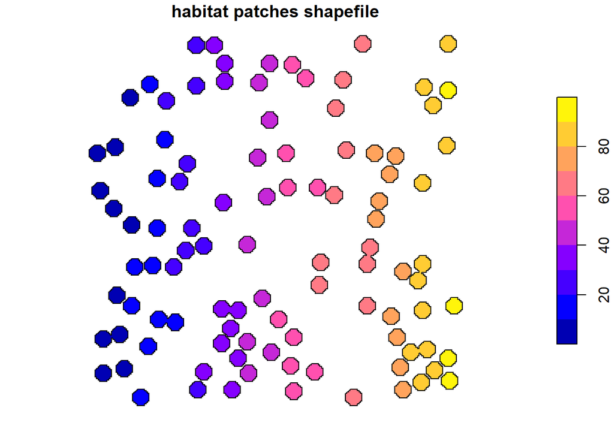

```r
  plot(hshp,main="habitat patches shapefile")
```

#### Step 3

Establish moving windows, using their center coordinate, side length (defined by “radius”), shape (square or circular), and overlap (defined by “incr”). Save centers as shape file.

```r
  ######
  ### 6.0) make a shapefile with centerpoints of moving windows
  centers = mkcenters(ext=ext,incr=incr)
```

```
## [1] "making centerpoints along extent..."
```

```r
  #### if a region of interest is given (roi), only use centers for region of interest
  ### 6.1) mask to region of interest if roi is provided, and set extent (used for centers below)
  if(sf::st_crs(centers)!=sf::st_crs(roi1)) {
      if(!is.na(sf::st_crs(centers))) {
          centers = sf::st_transform(centers,crs = sf::st_crs(roi1))
          } else if(is.na(sf::st_crs(centers))) {
            sf::st_crs(centers) =  sf::st_crs(roi1)
           }
         }
  centers = sf::st_intersection(centers,roi1)

  ### write centers shapefile to file, it contains the IDs and corresponding moving window center locations!
  if(file.exists(paste(respath,sprintf("centers_res%0.0f_rad%0.0f_incr%0.0f_habi%s.shp",resolution,radius,incr,habi),
                       sep='/'))) { file.remove(paste(respath,sprintf("centers_res%0.0f_rad%0.0f_incr%0.0f_habi%s.shp",resolution,radius,incr,habi),sep='/'))}
```

```
## [1] TRUE
```

```r
  sf::st_write(centers, paste(respath,sprintf("centers_res%0.0f_rad%0.0f_incr%0.0f_habi%s.shp",resolution,radius,incr,habi),sep='/'), driver="ESRI Shapefile")  # create to a shapefile
```

```
## writing: substituting ENGCRS["Undefined Cartesian SRS with unknown unit"] for missing CRS
```

```
## Writing layer `centers_res1_rad80_incr50_habigreenpatch' to data source
##   `C:/Users/jacqu/Documents/MultiSCon/projects/Reconnect/Reconnect/data/Reconnect_demo/centers_res1_rad80_incr50_habigreenpatch.shp' using driver `ESRI Shapefile'
## Writing 36 features with 2 fields and geometry type Point.
```

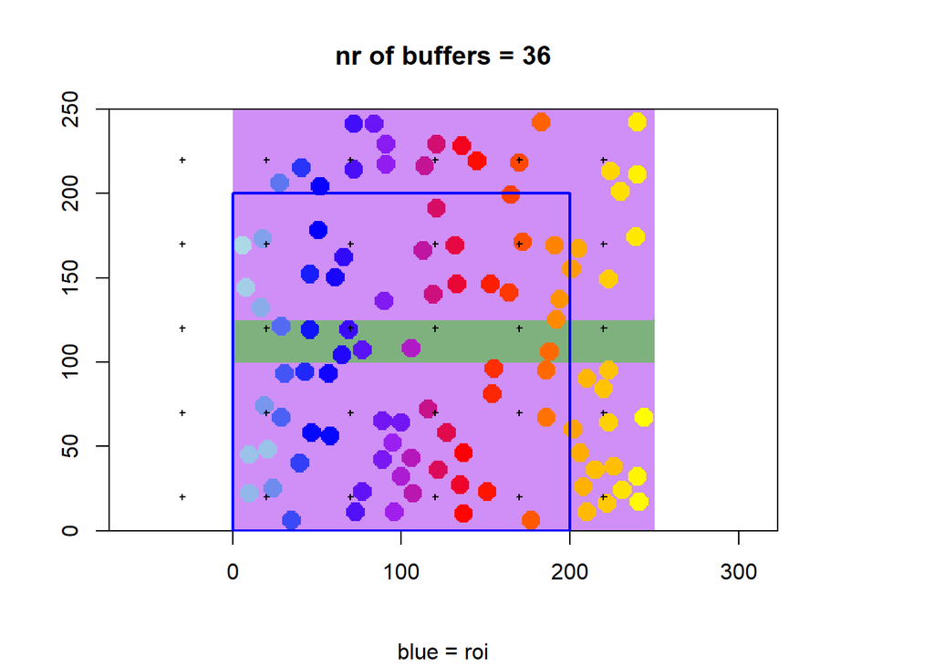

```r
  ####################################
  ## quick overview plot
  #if(oviewplot==TRUE) {
  #pdf(paste(respath,sprintf("Reconnect_ov_rad%0.0fm_res_%0.0fm_incr%0.0fm_%s.pdf",radius,resolution,incr,habi),sep="/"))
  ## plot all data
  #raster::plot(hr,col=rev(rcols(100)))
  ### take a small extent
  ext2 = ext*0.2
  ##plot(ext2)
  if(nlayers(hr)==2){
  raster::plot(hr[["resistance"]],col=adjustcolor(rev(rcols(100)),alpha.f=0.5),legend=FALSE,main=sprintf("nr of buffers = %d",length(centers$geometry)),sub="blue = roi")
  raster::plot(hr[["habitat"]],col=hcols(100),add=TRUE,legend=FALSE)
  } else if(nlayers(hr)==1) {raster::plot(hr[["habitat"]],col=hcols(100),legend=FALSE,sub="blue = roi")}
  plot(centers$geometry,add=TRUE,pch=3,cex=0.4,lwd=1.2,col="black")
  plot(roi$geometry,add=TRUE,border="blue",col=NA,lwd=2)
```

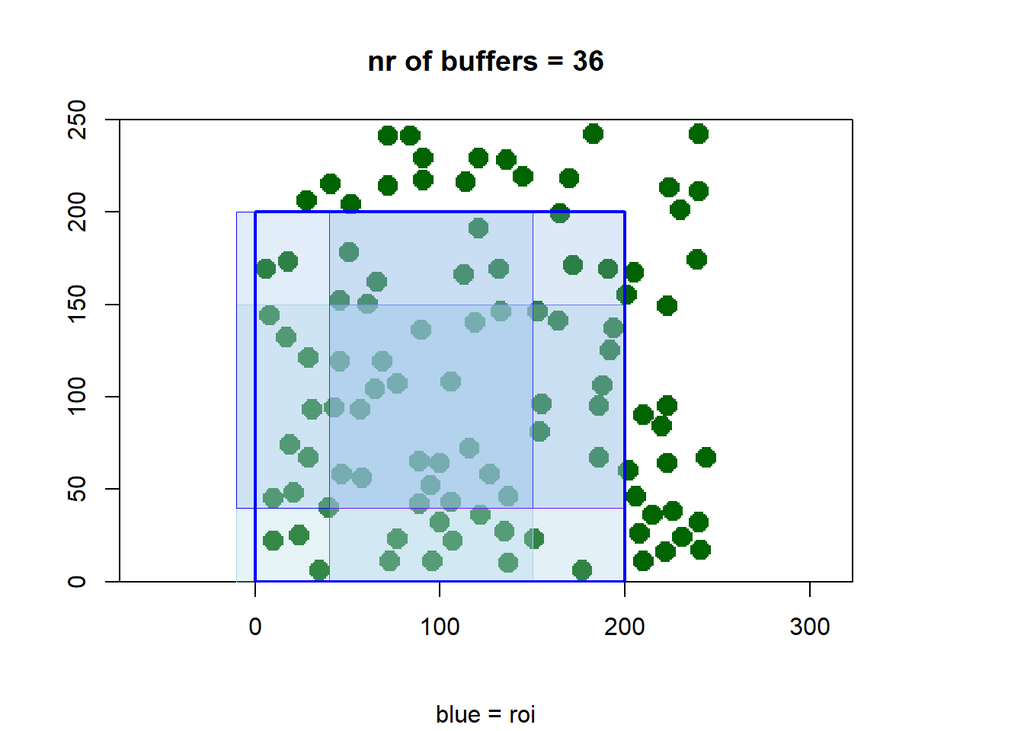

```r
  ## make a polygon of extent and extract center coordinates
  p         = st_as_sf(as(ext2, 'SpatialPolygons'))
  st_crs(p) = st_crs(centers)
  centers1  = centers[p,]
  ### make circular buffers
  sps = mkbuffer(centers=centers1,radius=radius,form=bufform)
  ## controlplot
  raster::plot(hr[["habitat"]],col="darkgreen",legend=FALSE,
               main=sprintf("nr of buffers = %d",length(centers$geometry)),sub="blue = roi")
  plot(sps$geometry,add=TRUE,col=adjustcolor(hcols(100),alpha.f=0.3),border=hcols(10),lwd=0.8)
  plot(roi$geometry,add=TRUE,border="blue",col=NA,lwd=2)
```

```r
  #dev.off()
  #} # overviewplot
```

#### Step 4

Set up for parallel processing of moving windows.

```r
  ## in case the user wants to specify start and end center IDs, it could be indicated here
  cst = NULL
  cen = NULL

  ######
  ### 7.0) start calculation of MULTIPLEX connectivity for connectivity indices x,y,z
  print(sprintf("start parallel moving windows %s...",habi))
```

```
## [1] "start parallel moving windows greenpatch..."
```

```r
  a = Sys.time()

  ## add packages to the environment in case not contained
  rpacks = unique(unlist(strsplit(cond$rpack,split=",")))
  rpacks = rpacks[rpacks!="NA"]

  ## add gdistance package to the packages if cost type != euclidean!
  if(cost_type!="euclidean"){rpacks = unique(c(rpacks,"gdistance"))}
  ## for parallelized treatment of patch IDs
  ## only registerdoparallel if cluster is not registered
  if(!foreach::getDoParRegistered()){
  doParallel::registerDoParallel(cores=ncores)
  }

  ## define nr of plots here
  nplot=ceiling(0.1*length(unique(centers$cid)))

  ## define the centerids for which calculations should be done
  if(length(cst)==0) {cst=1}
  if(length(cen)==0) {cen=length(unique(centers$cid))}

  ## apply function for each center ID

## parallel foreach loop:
  # foreach::foreach(cid=unique(centers$cid)[cst:cen],
  #                   .packages= unique(c("sf","raster","stars","terra","dismo","landscapemetrics",rpacks)),
  #                   .export  = ls(globalenv())
  #                   #.combine = rbind
  #  ) %dopar% {

  ### old version: regular for loop
 #for(cid in unique(centers$cid)) {
```

#### Step 5

Apply Reconnect_core function to all moving windows. For Demonstration purposes, this is shown here for 1 moving window

```r
########################################
##JO: only part of the DEMO
if(sci == 1) {cid = centers$cid[20]} else {cid = centers$cid[1] }

print(paste("center cid =",cid,sep=""))
```

```
## [1] "center cid =20"
```

```r
########################################

    ########################################
    ## 7.1) Determine focal area of interest for connectivity meausurements
    ## make square buffers
    foc = mkbuffer(centers=centers[centers[["cid"]]==cid,],radius=radius,form=bufform)

    ### extract raster information for buffer region of interest
    if(sf::st_crs(hr)!=sf::st_crs(foc)) {
      foc = sf::st_transform(foc,crs = sf::st_crs(hr))
    }

    ### JO: do this later! otherwise some patches are not correctly identified!
    ### extract shapefile of interest, determine if including or excluding patches at window boundaries
    #if(cutpatches==FALSE){shp1 = hshp[foc,]} else if(cutpatches==TRUE) {shp1 = sf::st_intersection(hshp,foc$geometry)}

    # ## make plots only for some fraction of landscapes treated
    # if ((cid/nplot)-floor(cid/nplot)==0) {
    #   pdf(paste(respath,sprintf("Reconnect_detail_rad%0.0fm_res_%0.0fm_cid%d_%s.pdf",radius,resolution,cid,habi),sep="/"))
    # }

    ########################################
    ## Start of Reconnect_core function
    ########################################
    pidname = names(hshp)[[1]]
    cols    = hcols(100)

    # Reconnect_core(cid=cid,pidname=pidname,hr=hr,foc=foc,hshp=hshp,minsizev=minsizev,
    #                   cutpatches=cutpatches,cond=cond,nplot=nplot,cols=cols,
    #                   cost_type  = cost_type,
    #                   dist_type  = dist_type,
    #                   trans_fun  = trans_fun,
    #                   neighb     = neighb,
    #                   areafun    = areafun,
    #                   maxnpatch  = maxnpatch,
    #                   radius     = radius,
    #                   resolution = resolution,
    #                   incr       = incr,
    #                   respath    = respath,
    #                   habi       = habi)
    #
    #
    # # ## plot finish closeup
    # if ((cid/nplot)-floor(cid/nplot)==0) {dev.off()} # plot
#   } # centers dopar
#   print(sprintf("all cid's finished..!"))
#   print(Sys.time()-a)
#   #closeAllConnections()
#   ### clean environment: remove not used objects
#   gc()
# } # sci = scale
# } # Reconnect_wrap end
```

### 6. The Reconnect_core function step by step

These steps will be carried out for each moving window determined by the centers shapefile.

The Reconnect_core function works on each focal moving window separately. It crops the habitat network with the current moving window (cutpatches = TRUE will cut patches beyond moving window boundaries) and establishes a dataframe for each scale of connectivity indicators (cf. level column in inifile). It applies the functions specified in the inifile (conname, resname, confun and statement columns in the inifile) within the focal moving window, for all the dispersal capacities (alphav) and corresponding minimum habitat patch requirements (minsizev) specified.

For an overview, lets plot the habitat patch network and current moving window of interest:

```r
########################################
##JO: only part of the DEMO

## for each pixel in moving window (pid = pixel number), there is an associated value according to function specified in inifile
print(head(dfpi))
```

```
##   pid minsize alpha  metric    value level cid radius resolution incr
## 2   1       0    NA eucdist 25.17936 pixel  20     80          1   50
## 3   2       0    NA eucdist 25.07987 pixel  20     80          1   50
## 4   3       0    NA eucdist 24.69818 pixel  20     80          1   50
## 5   4       0    NA eucdist 24.18677 pixel  20     80          1   50
## 6   5       0    NA eucdist 23.70654 pixel  20     80          1   50
## 7   6       0    NA eucdist 23.25941 pixel  20     80          1   50
```

```r
## for each habitat patch in moving window (pid = patch ID according to hshp shapefile), there is an associated value according to function specified in inifile
print(head(dfpa))
```

```
##   pid minsize alpha metric  value level cid radius resolution incr
## 2  21       0    NA  pa_ha 0.0005 patch  20     80          1   50
## 3  20       0    NA  pa_ha 0.0097 patch  20     80          1   50
## 4   6       0    NA  pa_ha 0.0097 patch  20     80          1   50
## 5   1       0    NA  pa_ha 0.0097 patch  20     80          1   50
## 6  25       0    NA  pa_ha 0.0097 patch  20     80          1   50
## 7  17       0    NA  pa_ha 0.0097 patch  20     80          1   50
```

```r
## for each moving window landscape (pid = "all" since only 1 value per moving window landcape), there is an associated value according to function specified in inifile
print(head(dfla))
```

```
##   pid minsize alpha  metric        value     level cid radius resolution incr
## 2 all       0    NA  foc_ha 2.560000e+00 landscape  20     80          1   50
## 3 all       0    NA  npatch 2.800000e+01 landscape  20     80          1   50
## 4 all       0    NA  tpa_ha 2.614000e-01 landscape  20     80          1   50
## 5 all       0    NA mnpa_ha 9.335714e-03 landscape  20     80          1   50
## 6 all       0    10  MPCraw 4.060169e+03 landscape  20     80          1   50
## 7 all       0    10 MPCdens 1.553240e+00 landscape  20     80          1   50
```

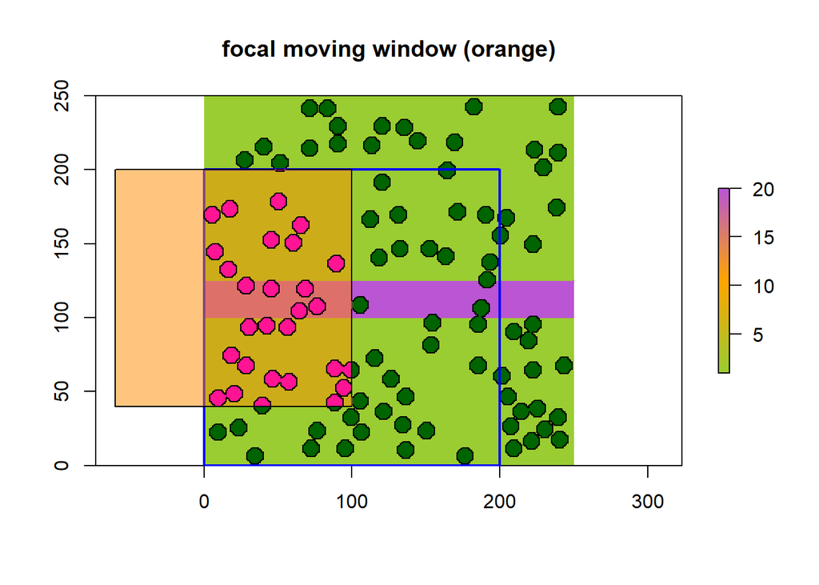

```r
## all these data are being written to a csv file, i.e. there is a csv file for each moving window, and level of aggregation (pixel, patch, landscape)

## the associated habitat landscape under consideration is as follows:
plot(hr[["resistance"]],col=JOcolsr1(100),main="focal moving window (orange)")
plot(hshp$geometry,col="darkgreen",add=TRUE)
plot(roi$geometry,add=TRUE,col=NA,border="blue",lwd=2)
plot(foc1$geometry,add=TRUE,col=adjustcolor("darkorange",alpha.f=0.5))
plot(shp1$geometry, col="deeppink",add=TRUE)
```

### 7. Lets run the Reconnect_wrap (includes Reconnect_core) function for all moving windows and scales defined in scaledf!

```r
for (sci in 1:nrow(scaledf)) {
  #sci = 1
  print(sprintf("---Reconnect calculation scale = %d---",sci))
  #resolution = resolution1; radius = radius1; incr = incr1;
  resolution = scaledf[sci,"resolution"]
  radius     = scaledf[sci,"radius"]
  incr       = scaledf[sci,"incr"]

Reconnect_wrap(lcr=lcr,lres=lres,roi=roi,cond=cond,respath=respath,resolution=resolution,radius=radius,incr=incr,
          habi=habi,bufform=bufform,minsizev=minsizev,cutpatches=cutpatches,
          ncores=ncores,
          cost_type=cost_type,dist_type=dist_type,trans_fun=trans_fun,neighb=neighb,areafun=areafun,
          oviewplot=oviewplot,maxnpatch = maxnpatch)

} # sci = scale
```

```
## [1] "---Reconnect calculation scale = 1---"
## [1] "resolution=1m, radius=80m, increment=50m..."
## [1] "found 94 patches.."
```

```
## writing: substituting ENGCRS["Undefined Cartesian SRS with unknown unit"] for missing CRS
```

```
## Writing layer `hshp_res1_rad80_incr50_habigreenpatch' to data source
##   `C:/Users/jacqu/Documents/MultiSCon/projects/Reconnect/Reconnect/data/Reconnect_demo/hshp_res1_rad80_incr50_habigreenpatch.shp' using driver `ESRI Shapefile'
## Writing 94 features with 1 fields and geometry type Polygon.
## [1] "making centerpoints along extent..."
```

```
## writing: substituting ENGCRS["Undefined Cartesian SRS with unknown unit"] for missing CRS
```

```
## Writing layer `centers_res1_rad80_incr50_habigreenpatch' to data source
##   `C:/Users/jacqu/Documents/MultiSCon/projects/Reconnect/Reconnect/data/Reconnect_demo/centers_res1_rad80_incr50_habigreenpatch.shp' using driver `ESRI Shapefile'
## Writing 36 features with 2 fields and geometry type Point.
```

```
## [1] "start parallel moving windows greenpatch..."
## [1] "all cid's finished..!"
## Time difference of 23.65945 secs
## [1] "---Reconnect calculation scale = 2---"
## [1] "resolution=10m, radius=125m, increment=NAm..."
## [1] "found 9 patches.."
```

```
## writing: substituting ENGCRS["Undefined Cartesian SRS with unknown unit"] for missing CRS
```

```
## Writing layer `hshp_res10_rad125_incrNA_habigreenpatch' to data source
##   `C:/Users/jacqu/Documents/MultiSCon/projects/Reconnect/Reconnect/data/Reconnect_demo/hshp_res10_rad125_incrNA_habigreenpatch.shp' using driver `ESRI Shapefile'
## Writing 9 features with 1 fields and geometry type Polygon.
## [1] "make only one centerpoint..."
```

```
## writing: substituting ENGCRS["Undefined Cartesian SRS with unknown unit"] for missing CRS
```

```
## Writing layer `centers_res10_rad125_incrNA_habigreenpatch' to data source
##   `C:/Users/jacqu/Documents/MultiSCon/projects/Reconnect/Reconnect/data/Reconnect_demo/centers_res10_rad125_incrNA_habigreenpatch.shp' using driver `ESRI Shapefile'
## Writing 1 features with 2 fields and geometry type Point.
```

```
## [1] "start parallel moving windows greenpatch..."
## [1] "all cid's finished..!"
## Time difference of 0.3911319 secs
```

### 8. Run the Reconnect summarize function to aggregate outputs at patch pixel and landscape level

This function aggregates all data of the moving windows together in order to create landscape mosaics (with the aggregation specified in mosafun).

### 9. Check results

Results at pixel and landscape level consist of tif files, results at patch level consist of shapefiles with habitat patches and corresponding patch-values! An explanation of all Reconnect functions and connectivity indicators can be accessed on Github in the Documentation (doc) folder: https://github.com/oehrij/Reconnect/blob/main/doc/Reconnect_framework_description_v1.pdf

```r
files = list.files(respath2)
print(files)
```

```
##  [1] "Reconnectland_BC_rad125m_res_10m_incr_NAm_greenpatch.pdf"
##  [2] "Reconnectland_BC_rad125m_res_10m_incr_NAm_greenpatch.tif"
##  [3] "Reconnectland_BC_rad80m_res_1m_incr_50m_greenpatch.pdf"
##  [4] "Reconnectland_BC_rad80m_res_1m_incr_50m_greenpatch.tif"
##  [5] "Reconnectland_ECA_AP_rad125m_res_10m_incr_NAm_greenpatch.pdf"
##  [6] "Reconnectland_ECA_AP_rad125m_res_10m_incr_NAm_greenpatch.tif"
##  [7] "Reconnectland_ECA_AP_rad80m_res_1m_incr_50m_greenpatch.pdf"
##  [8] "Reconnectland_ECA_AP_rad80m_res_1m_incr_50m_greenpatch.tif"
##  [9] "Reconnectland_ECA_rad125m_res_10m_incr_NAm_greenpatch.pdf"
## [10] "Reconnectland_ECA_rad125m_res_10m_incr_NAm_greenpatch.tif"
## [11] "Reconnectland_ECA_rad80m_res_1m_incr_50m_greenpatch.pdf"
## [12] "Reconnectland_ECA_rad80m_res_1m_incr_50m_greenpatch.tif"
## [13] "Reconnectland_ECAimp_rad125m_res_10m_incr_NAm_greenpatch.pdf"
## [14] "Reconnectland_ECAimp_rad125m_res_10m_incr_NAm_greenpatch.tif"
## [15] "Reconnectland_ECAimp_rad80m_res_1m_incr_50m_greenpatch.pdf"
```

[output cut: 61 more lines]

```
## [1] "Reconnectland_BC_rad125m_res_10m_incr_NAm_greenpatch.tif"
```

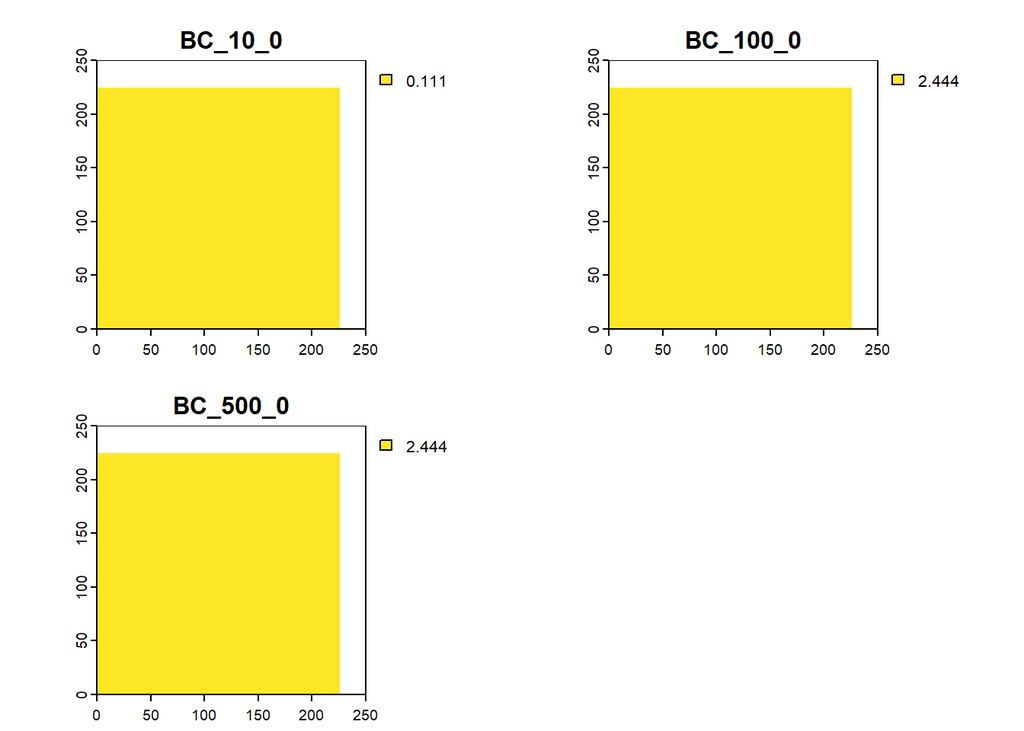

```
## [1] "Reconnectland_BC_rad80m_res_1m_incr_50m_greenpatch.tif"
```

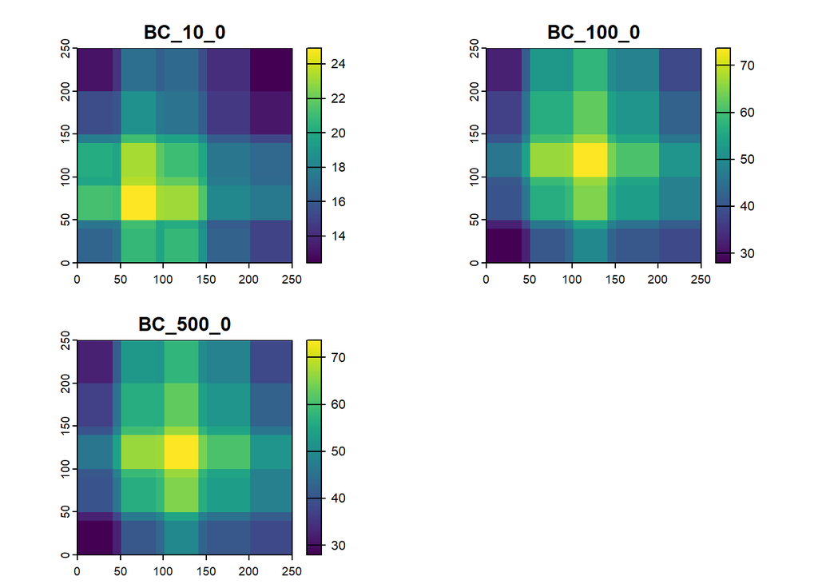

```
## [1] "Reconnectland_ECA_AP_rad125m_res_10m_incr_NAm_greenpatch.tif"
```

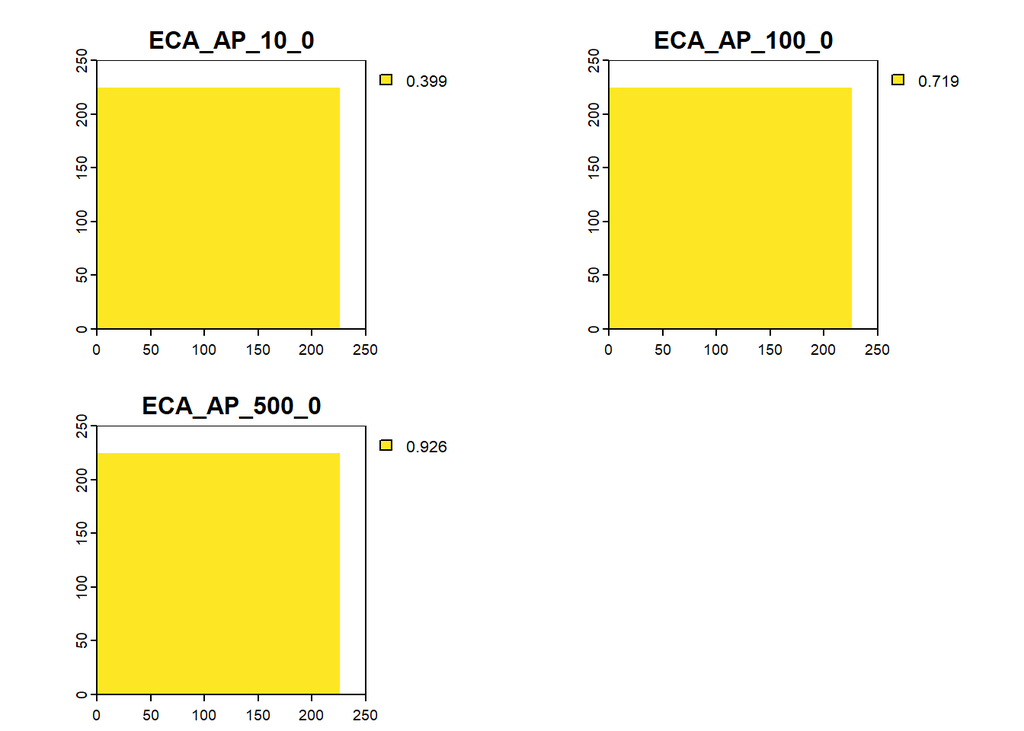

```
## [1] "Reconnectland_ECA_AP_rad80m_res_1m_incr_50m_greenpatch.tif"
```

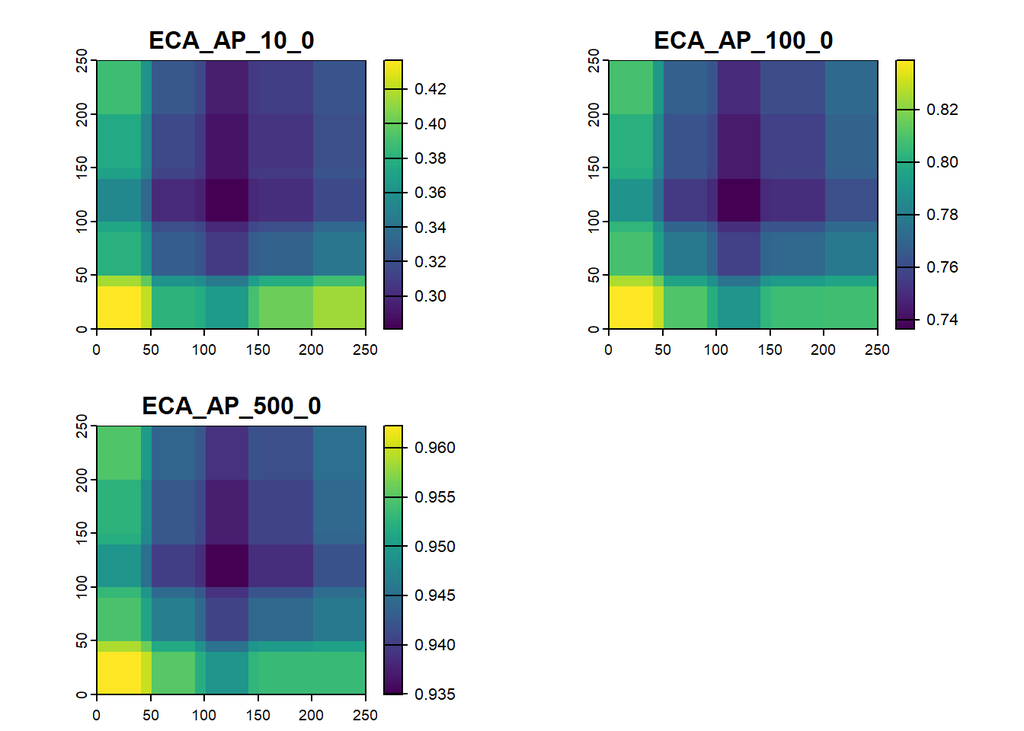

```
## [1] "Reconnectland_ECA_rad125m_res_10m_incr_NAm_greenpatch.tif"
```

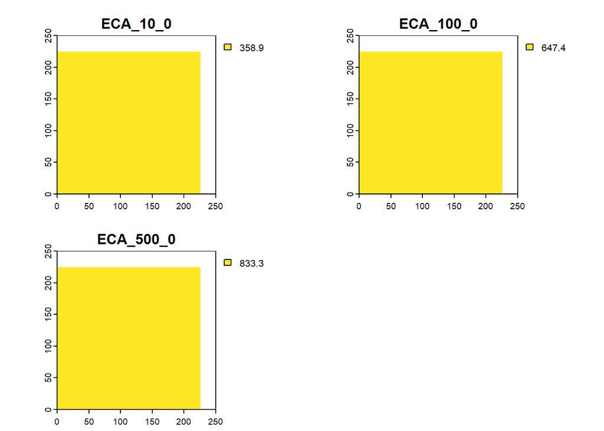

```
## [1] "Reconnectland_ECA_rad80m_res_1m_incr_50m_greenpatch.tif"
```

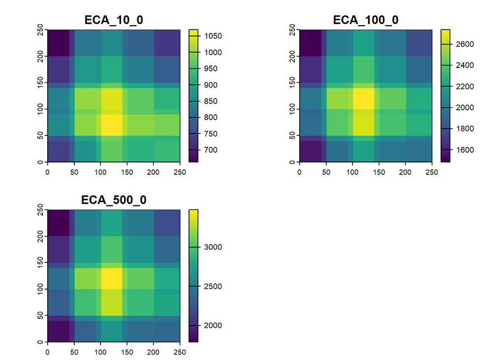

```
## [1] "Reconnectland_ECAimp_rad125m_res_10m_incr_NAm_greenpatch.tif"
```

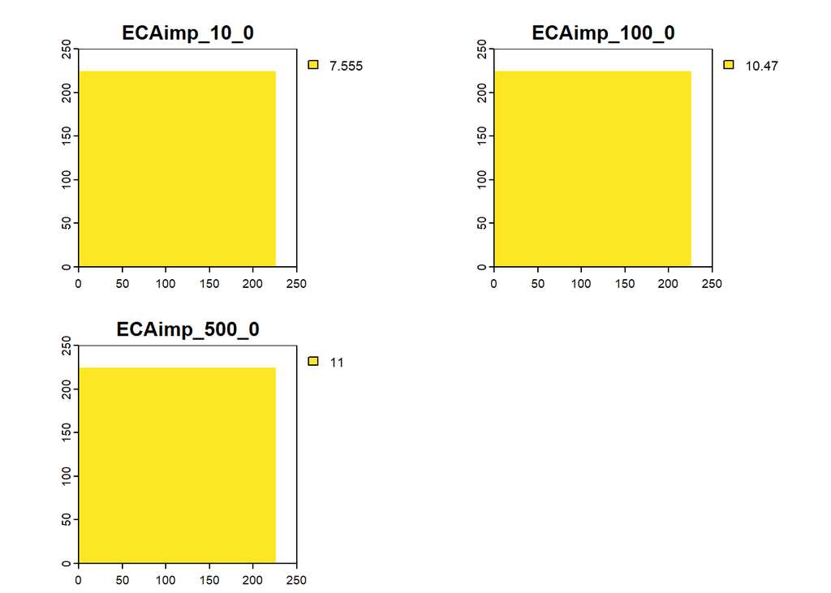

```
## [1] "Reconnectland_ECAimp_rad80m_res_1m_incr_50m_greenpatch.tif"
```

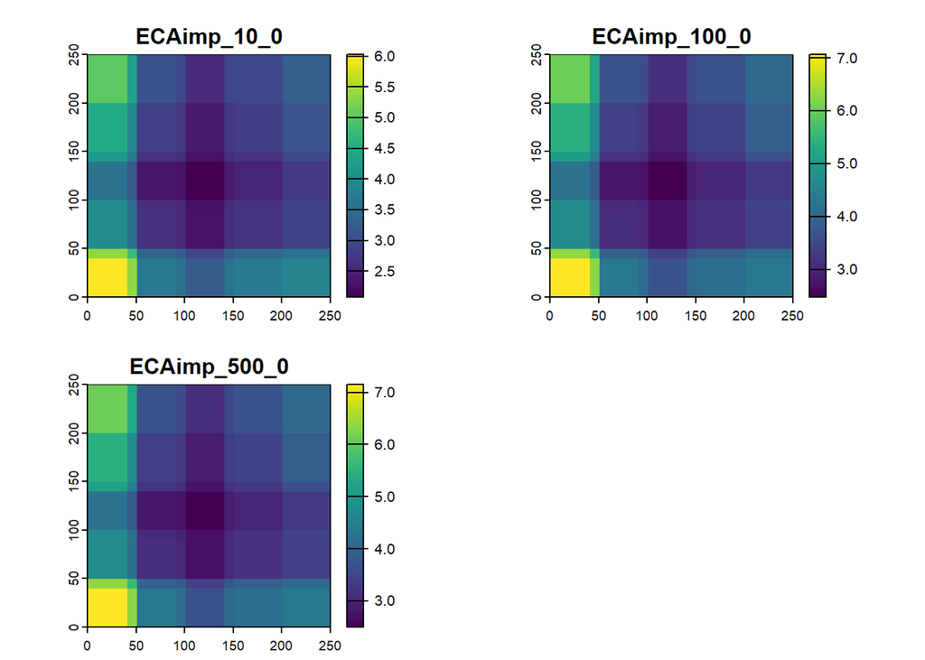

```
## [1] "Reconnectland_eucdist_rad125m_res_10m_incr_NAm_greenpatch.tif"
```

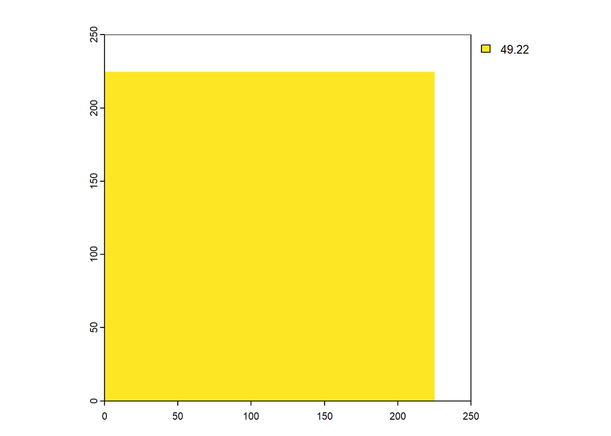

```
## [1] "Reconnectland_eucdist_rad80m_res_1m_incr_50m_greenpatch.tif"
```

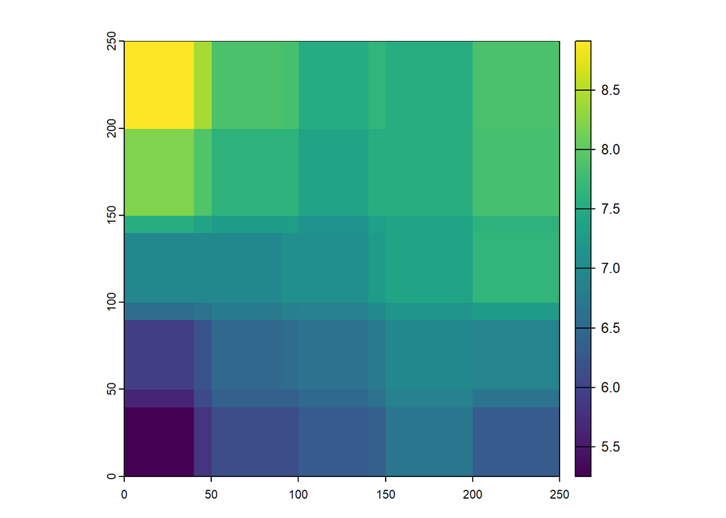

```
## [1] "Reconnectland_foc_ha_rad125m_res_10m_incr_NAm_greenpatch.tif"
```

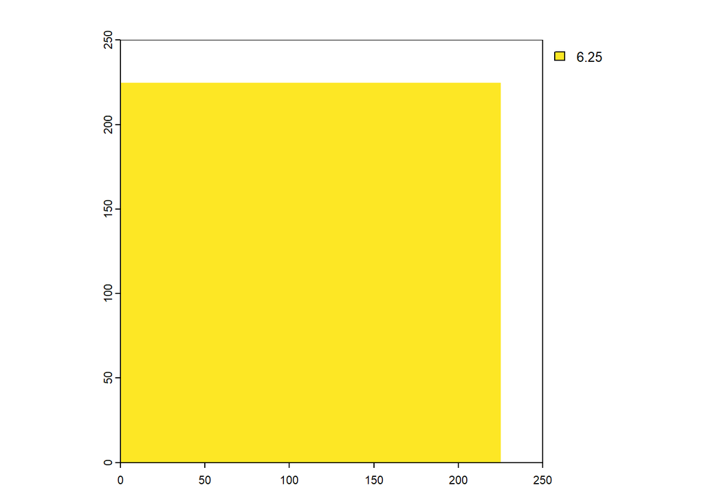

```
## [1] "Reconnectland_foc_ha_rad80m_res_1m_incr_50m_greenpatch.tif"
```

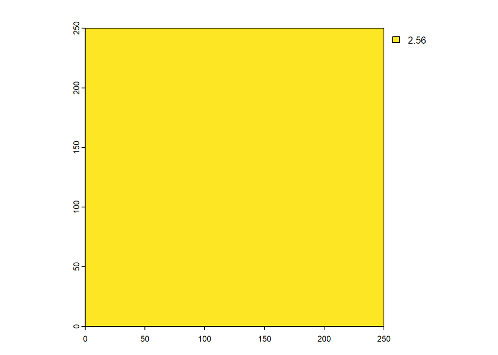

```
## [1] "Reconnectland_mnpa_ha_rad125m_res_10m_incr_NAm_greenpatch.tif"
```

[20 more figures not shown]

```r
tifs = files[grep(".tif$",files)]
shps = files[grep(".shp$",files)]

for(tt in tifs) {
 print(tt)
 tres = terra::rast(paste0(respath2,"/",tt))
 plot(tres)

}
```

```
## [1] "Reconnectpa125m10mNAmgreenpatch.shp"
```

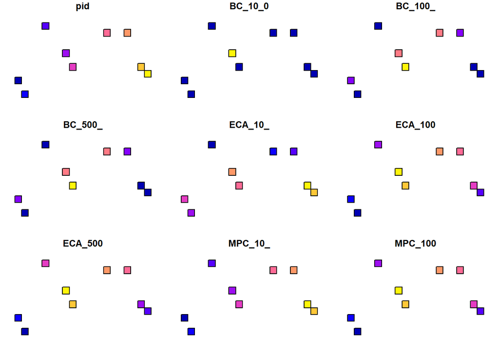

```
## [1] "Reconnectpa80m1m50mgreenpatch.shp"
```

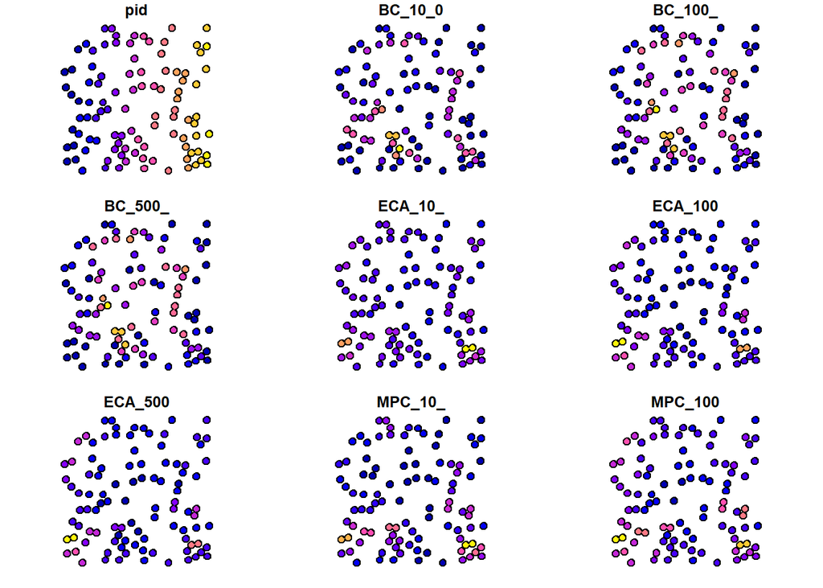

```r
for(tt in shps) {
 print(tt)
 tres = sf::st_read(paste0(respath2,"/",tt))
 plot(tres)
}
```

### 10. Calculate multispecies Connectivity for one landscape using Reconnect_single

```
## [1] "Single_hr_IDhabi_test_res_1m.tif"
```

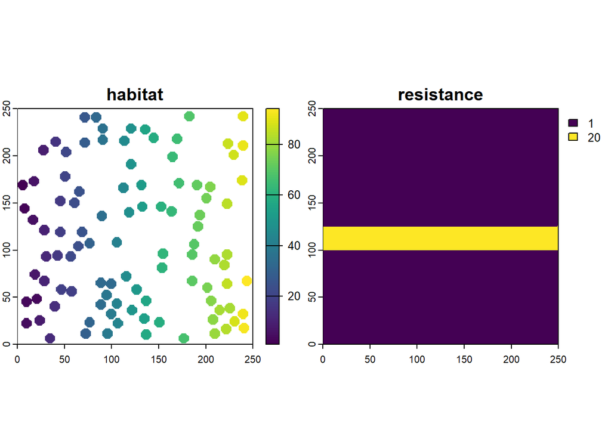

```r
## look at Reconnect_simple results
files = list.files(respath)
tifs = files[grep("^Single.+.tif$",files)]
shps = files[grep("^Single.+.shp$",files)]
csvs = files[grep("^Single.+.csv$",files)]

for(tt in tifs) {
 print(tt)
 tres = terra::rast(paste0(respath,"/",tt))
 plot(tres)
}
```

```
## [1] "Single_hshp_IDhabi_test_res1.shp"
```

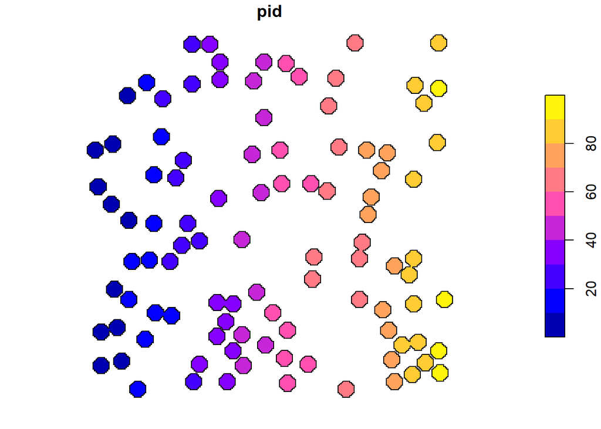

```r
for(tt in shps) {
 print(tt)
 tres = sf::st_read(paste0(respath,"/",tt))
 plot(tres)
}
```

```r
for(tt in csvs) {
 print(tt)
 tres = read.csv(paste0(respath,"/",tt))
 print(summary(tres))
}
```

```
## [1] "Single_dfla_res_1m_cid_habi_test.csv"
##      pid               minsize      alpha          metric
##  Length:33          Min.   :0   Min.   : 10.0   Length:33
##  Class :character   1st Qu.:0   1st Qu.: 10.0   Class :character
##  Mode  :character   Median :0   Median :100.0   Mode  :character
##                     Mean   :0   Mean   :203.3
##                     3rd Qu.:0   3rd Qu.:500.0
##                     Max.   :0   Max.   :500.0
##                                 NA's   :6
##      value             level               cid              resolution
##  Min.   :  -99.00   Length:33          Length:33          Min.   :1
##  1st Qu.:    0.01   Class :character   Class :character   1st Qu.:1
##  Median :    0.81   Mode  :character   Mode  :character   Median :1
##  Mean   : 3023.15                                         Mean   :1
##  3rd Qu.:    6.84                                         3rd Qu.:1
##  Max.   :53531.40                                         Max.   :1
##
## [1] "Single_dfpa_res_1m_cid_habi_test.csv"
##       pid           minsize      alpha          metric
##  Min.   : 1.00   Min.   :0   Min.   : 10.0   Length:896
##  1st Qu.:18.75   1st Qu.:0   1st Qu.: 10.0   Class :character
##  Median :39.50   Median :0   Median :100.0   Mode  :character
##  Mean   :38.75   Mean   :0   Mean   :203.3
##  3rd Qu.:59.25   3rd Qu.:0   3rd Qu.:500.0
##  Max.   :77.00   Max.   :0   Max.   :500.0
##                              NA's   :128
##      value             level               cid              resolution
##  Min.   :-99.0000   Length:896         Length:896         Min.   :1
##  1st Qu.:-99.0000   Class :character   Class :character   1st Qu.:1
##  Median :  0.0097   Mode  :character   Mode  :character   Median :1
##  Mean   :-41.7529                                         Mean   :1
##  3rd Qu.:  0.8444                                         3rd Qu.:1
##  Max.   : 19.2094                                         Max.   :1
##
## [1] "Single_dfpi_res_1m_cid_habi_test.csv"
##       pid           minsize   alpha            metric              value
##  Min.   :    1   Min.   :0   Mode:logical   Length:40000       Min.   : 0.000
##  1st Qu.:10001   1st Qu.:0   NA's:40000     Class :character   1st Qu.: 2.000
##  Median :20001   Median :0                  Mode  :character   Median : 5.831
##  Mean   :20001   Mean   :0                                     Mean   : 6.840
##  3rd Qu.:30000   3rd Qu.:0                                     3rd Qu.:10.296
##  Max.   :40000   Max.   :0                                     Max.   :31.145
##     level               cid              resolution
##  Length:40000       Length:40000       Min.   :1
##  Class :character   Class :character   1st Qu.:1
##  Mode  :character   Mode  :character   Median :1
##                                        Mean   :1
##                                        3rd Qu.:1
##                                        Max.   :1
```

## References

- Albert, C. H., Rayfield, B., Dumitru, M., & Gonzalez, A. (2017). Applying network theory to prioritize multispecies habitat networks that are robust to climate and land-use change. Conservation Biology, 31(6), 1383–1396.
- Csardi, G., & Nepusz, T. (2006). The igraph software package for complex network research. InterJournal, Complex Systems, 1695.
- Drielsma, M., & Ferrier, S. (2009). Rapid evaluation of metapopulation persistence in highly variegated landscapes. Biological Conservation, 142(3), 529–540.
- van Etten, J. (2017). r packagegdistance : distances and routes on geographical grids. Journal of Statistical Software, 76(13).
- Godínez-Gómez, O. and Correa Ayram C.A. (2020). Makurhini: Analyzing landscape connectivity. Computer software, https://github.com/connectscape/Makurhini.
- Hartfelder, J., Reynolds, C., Stanton, R. A., Sibiya, M., Monadjem, A., McCleery, R. A., & Fletcher, R. J. (2020). The allometry of movement predicts the connectivity of communities. Proceedings of the National Academy of Sciences of the United States of America, 117(36), 22274–22280.
- Hesselbarth, M. H. K., Sciaini, M., With, K. A., Wiegand, K., & Nowosad, J. (2019). landscapemetrics : an open‐source R tool to calculate landscape metrics. Ecography.
- Huang, R., Pimm, S. L., & Giri, C. (2020). Using metapopulation theory for practical conservation of mangrove endemic birds. Conservation Biology, 34(1), 266–275.
- Hughes, J., Lucet, V., Barrett, G., Moran, S., Manseau, M., Martin, A. E., Naujokaitis-Lewis, I., et al. (2022). Comparison and Parallel Implementation of Alternative Moving-Window Metrics of the Connectivity of Protected Areas Across Large Landscapes. Research square.
- Hutchinson, M. C., Bramon Mora, B., Pilosof, S., Barner, A. K., Kéfi, S., Thébault, E., Jordano, P., et al. (2018). Seeing the forest for the trees: putting multilayer networks to work for community ecology. Functional Ecology.
- Koen, E. L., Ellington, E. H., & Bowman, J. (2019). Mapping landscape connectivity for large spatial extents. Landscape Ecology, 34(10), 2421–2433.
- Liu, C., Newell, G., White, M., & Bennett, A. F. (2018). Identifying wildlife corridors for the restoration of regional habitat connectivity: A multispecies approach and comparison of resistance surfaces. Plos One, 13(11), e0206071.
- Meurant, M., Gonzalez, A., Doxa, A., & Albert, C. H. (2018). Selecting surrogate species for connectivity conservation. Biological Conservation, 227, 326–334.
- Pilosof, S., Porter, M. A., Pascual, M., & Kéfi, S. (2017). The multilayer nature of ecological networks. Nature Ecology & Evolution, 1(4), 101.
- Rayfield, B, Larocque, G., Daniel, C., & Gonzalez, A. (n.d.). Une priorisation pour la conservation des milieux naturels des Basses-Terres du Saint-Laurent en fonction de leur importance pour la connectivité.
- Rayfield, Bronwyn, Pelletier, D., Dumitru, M., Cardille, J. A., & Gonzalez, A. (2016). Multipurpose habitat networks for short-range and long-range connectivity: a new method combining graph and circuit connectivity. Methods in Ecology and Evolution, 7(2), 222–231.
- Rezaei, S., Mohammadi, A., Malakoutikhah, S., & Khosravi, R. (2022). Combining multiscale niche modeling, landscape connectivity, and gap analysis to prioritize habitats for conservation of striped hyaena (Hyaena hyaena). Plos One, 17(2), e0260807.
- Salgueiro, P. A., Valerio, F., Silva, C., Mira, A., Rabaça, J. E., & Santos, S. M. (2021). Multispecies landscape functional connectivity enhances local bird species’ diversity in a highly fragmented landscape. Journal of Environmental Management, 284, 112066.
- Shahnaseri, G., Hemami, M.-R., Khosravi, R., Malakoutikhah, S., Omidi, M., & Cushman, S. A. (2019). Contrasting use of habitat, landscape elements, and corridors by grey wolf and golden jackal in central Iran. Landscape Ecology, 34(6), 1263–1277.
- Strimas-Mackey, M., & Brodie, J. F. (2018). Reserve design to optimize the long-term persistence of multiple species. Ecological Applications, 28(5), 1354–1361.
- Tarabon, S., Bergès, L., Dutoit, T., & Isselin-Nondedeu, F. (2019). Environmental impact assessment of development projects improved by merging species distribution and habitat connectivity modelling. Journal of Environmental Management, 241, 439–449.